# Problem Set 08

Lauren Sullivan, BIO_SC 8002_01

Due April 22, 2022

## Rattlesnake morphometrics

### Background

We will be examining data from: Smith and Collyer 2008. In: [The Biology of Rattlesnakes](https://www.si.edu/object/siris_sil_946502). This is adapted from work by Dean Adams at Iowa State University.

The authors worked with 107 live prairie rattlesnakes to examine how different factors altered their head shape. Their independent variables included: region the snake was found in (Central, East, West), sex (male, female), and a measure of total body length - snout to vent length (SVL). Their dependent variables included a measurement of the outline distance of the head (head_shape), as well as a series of morphometric point measurements across the head at known regions (regions) that are a multivariate demonstration of head shape. The authors explored their snakes using both a univariate and a multivariate approach. In this homework, we will determine which approach is the most appropriate.

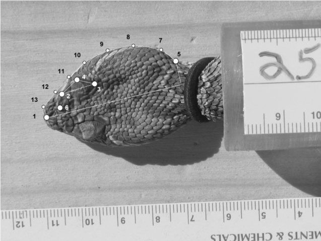

Where Smith and Collyer measured morphometric regions on the snake heads

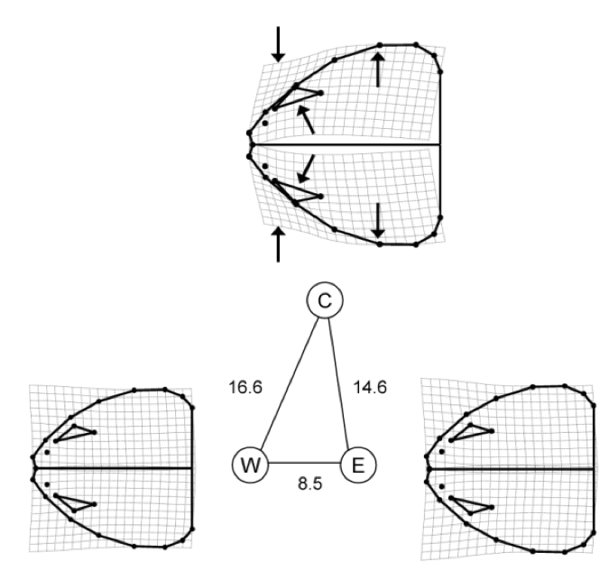

2D spline representation of the snake head location measurements from the central region (C) where snakes live in snady mammal burrows, and the east and west regions (E and W) where snakes live in rocky buttes.

## Univariate Model

**Q1** We will start with the univariate models, and will be examining if head shape is a function of the sex of a snake, and the region it is from. Let’s look at our data first. Create an appropriate plot to demonstrate the mean head shape (displayed as a point with error bars representing the standard error) of male and female snakes from different regions.

**Q2** Run the correct univariate model to examine $headshape \sim Region * Sex$. What is this model called? What are the results of the model?

**Q3** It might also be important to take into account the overall size of each snake. Run the correct univariate model to examine how Region, Sex and SVL affect head shape. What does your model look like and why did you choose that formulation? What is this model called? What are the results of the model? Create a figure that demonstrates this result.

## Multivariate Models

**Q4** Ok, so there appears to be an interesting univariate pattern, but what about with the multivariate head shape data? Do we see different patterns when we look at more than one measurement of head shape? Let’s start by cleaning our data. You can see in our dataset snakes we have one column called “region” and there are 15 places where measurements were taken (RW1 - RW15), and their associated measurement value is in the “location” column. Tidy this data so you have one column for each of the 15 regions measured.

**Q5** You can now ignore the column for headshape, and consider our new set of Y variables to be RW1 - RW15. Run the MANCOVA that explores the relationship between **Y** and Region, Sex and SVL. What model do you find the most support for and why?

**Q6** Create a figure that visualizes your model. Extract the PC1 axis as a representation of your **Y** for your y axis, and have your x axis be SVL, with different colors/shapes for Region and Sex as before. How do you interpret this figure?

**Q7** Based on your results from your univariate and multivariate models, what analysis would you report on? You get different results depending on which model you choose, so why would you choose this one?